# Tugas Praktikum 2

Qaulan Sadiida Putri Sumarna

2025-08-29

# Library

```r
library("forecast")
```

```r
library("graphics")
library("TTR")
library("TSA")
library(rio)
library(tseries)
library(ggplot2)
```

# Import Data

```r
data_minyak <- import("https://raw.githubusercontent.com/Sadiida/mpdw/main/Pertemuan%202/Data/crude-oil-price.csv")
head(data_minyak)
```

```
##         date price percentChange change
## 1 1983-03-01 29.27            NA     NA
## 2 1983-04-01 30.63         4.646   1.36
## 3 1983-05-01 30.25        -1.241  -0.38
## 4 1983-06-01 31.38         3.736   1.13
## 5 1983-07-01 32.00         1.976   0.62
## 6 1983-08-01 31.59        -1.281  -0.41
```

# Memilih data

```r
dt <- data_minyak[128:254, c(1, 2) ]
head(dt)
```

```
##           date price
## 128 1993-10-01 16.92
## 129 1993-11-01 15.43
## 130 1993-12-01 14.17
## 131 1994-01-01 15.19
## 132 1994-02-01 14.48
## 133 1994-03-01 14.79
```

# Eksplorasi Data

```r
View(dt)
str(dt)
```

```
## 'data.frame':    127 obs. of  2 variables:
##  $ date : POSIXct, format: "1993-10-01" "1993-11-01" ...
##  $ price: num  16.9 15.4 14.2 15.2 14.5 ...
```

```r
dim(dt)
```

```
## [1] 127   2
```

## Mengubah data agar terbaca sebagai data deret waktu

```r
dt.ts <- ts(dt$price)
summary(dt.ts)
```

```
##    Min. 1st Qu.  Median    Mean 3rd Qu.    Max.
##   11.22   17.95   21.08   22.70   27.25   37.38
```

## Plot data deret waktu

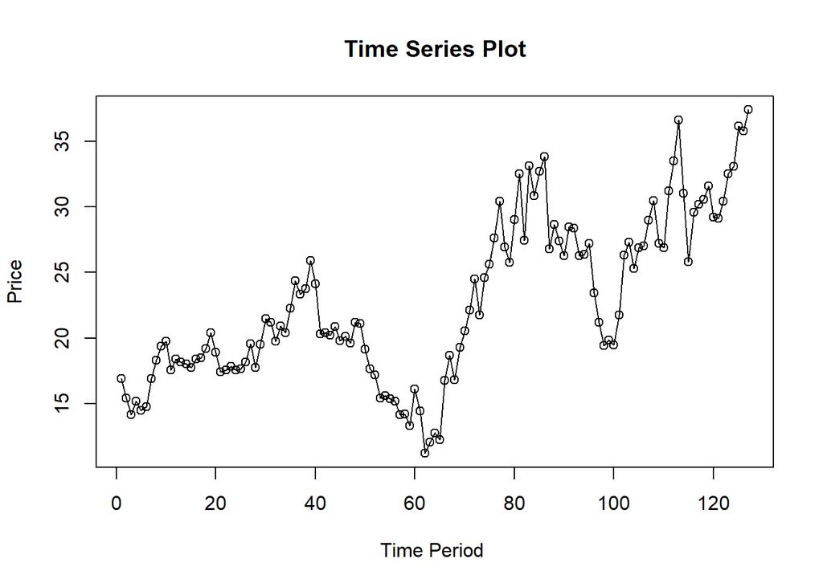

```r
ts.plot(dt.ts, xlab="Time Period ", ylab="Price",
        main = "Time Series Plot")
points(dt.ts)
```

# SMA & DMA

```r
# hitung jumlah data
n <- nrow(dt)

# tentukan batas 80%
n_train <- floor(0.8 * n)

# bagi data
training_ma <- dt[1:n_train, ]
testing_ma  <- dt[(n_train+1):n, ]

# ubah ke time series
train_ma.ts <- ts(training_ma$price)
test_ma.ts  <- ts(testing_ma$price)
```

## Plot data

### data latih

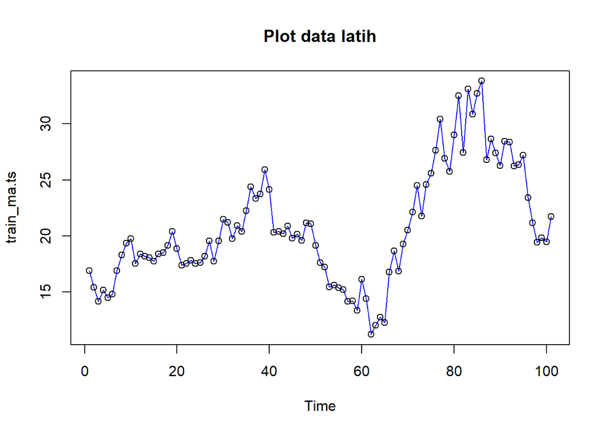

```r
plot(train_ma.ts, col="blue",main="Plot data latih")
points(train_ma.ts)
```

### data uji

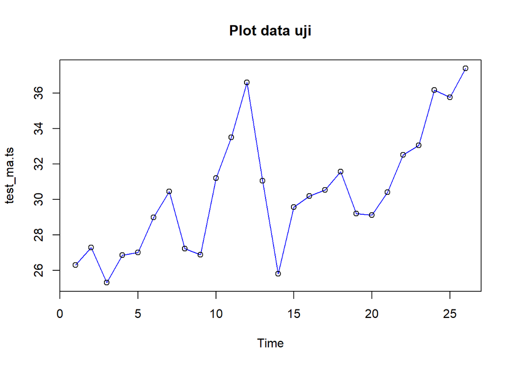

```r
#eksplorasi data uji
plot(test_ma.ts, col="blue",main="Plot data uji")
points(test_ma.ts)
```

### ggplot

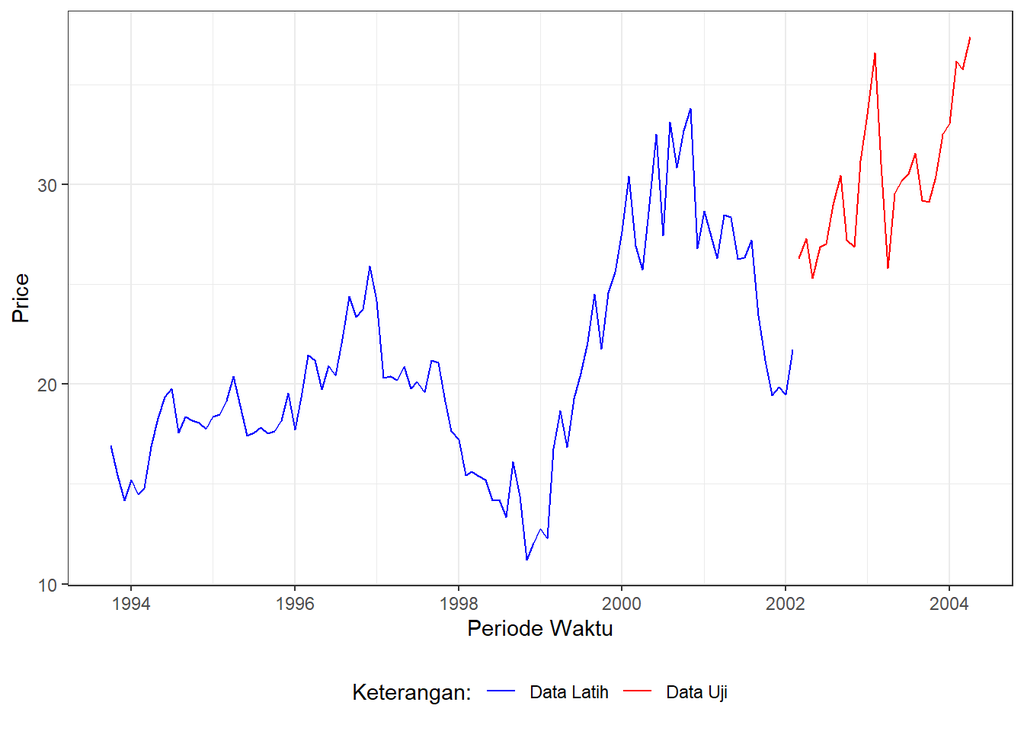

```r
ggplot() +
  geom_line(data = training_ma, aes(x = date, y = price, col = "Data Latih")) +
  geom_line(data = testing_ma, aes(x = date, y = price, col = "Data Uji")) +
  labs(x = "Periode Waktu", y = "Price", color = "Legend") +
   scale_colour_manual(name="Keterangan:", breaks = c("Data Latih", "Data Uji"),
                      values = c("blue", "red")) +
  theme_bw() + theme(legend.position = "bottom",
                     plot.caption = element_text(hjust=0.5, size=12))
```

## SMA (Single Moving Average)

```r
data.sma<-SMA(train_ma.ts, n=4)
data.sma
```

```
## Time Series:
## Start = 1
## End = 101
## Frequency = 1
##   [1]      NA      NA      NA 15.4275 14.8175 14.6575 15.3400 16.1200 17.3425
##  [10] 18.5875 18.7525 18.7725 18.4775 18.0475 18.0975 18.0975 18.1725 18.4525
##  [19] 19.1075 19.2325 18.9600 18.5575 17.9225 17.5850 17.6450 17.8000 18.2275
##  [28] 18.2775 18.7525 19.5750 19.9875 20.4925 20.8375 20.5750 20.8375 21.9925
##  [37] 22.6000 23.4325 24.3500 24.2925 23.5300 22.6950 21.2675 20.4500 20.3250
##  [46] 20.2575 20.1075 20.1825 20.5025 20.2550 19.7625 18.7700 17.3600 16.4750
##  [55] 15.9125 15.4100 15.0950 14.7450 14.2325 14.4675 14.5275 13.7800 13.4575
##  [64] 12.6100 12.0725 13.4575 15.1100 16.1325 17.8875 18.8300 19.6925 21.6100
##  [73] 22.2250 23.2400 24.1125 24.8950 27.0650 27.6425 27.6775 28.0200 28.5375
##  [82] 28.6700 30.5150 30.9725 31.0225 32.6200 31.0400 30.4950 29.1675 27.2850
##  [91] 27.7000 27.6275 27.3425 27.3575 27.0425 25.8075 24.5400 22.8125 20.9725
## [100] 19.9850 20.1250
```

```r
data.ramal<-c(NA,data.sma)
data.ramal #forecast 1 periode ke depan
```

```
##   [1]      NA      NA      NA      NA 15.4275 14.8175 14.6575 15.3400 16.1200
##  [10] 17.3425 18.5875 18.7525 18.7725 18.4775 18.0475 18.0975 18.0975 18.1725
##  [19] 18.4525 19.1075 19.2325 18.9600 18.5575 17.9225 17.5850 17.6450 17.8000
##  [28] 18.2275 18.2775 18.7525 19.5750 19.9875 20.4925 20.8375 20.5750 20.8375
##  [37] 21.9925 22.6000 23.4325 24.3500 24.2925 23.5300 22.6950 21.2675 20.4500
##  [46] 20.3250 20.2575 20.1075 20.1825 20.5025 20.2550 19.7625 18.7700 17.3600
##  [55] 16.4750 15.9125 15.4100 15.0950 14.7450 14.2325 14.4675 14.5275 13.7800
##  [64] 13.4575 12.6100 12.0725 13.4575 15.1100 16.1325 17.8875 18.8300 19.6925
##  [73] 21.6100 22.2250 23.2400 24.1125 24.8950 27.0650 27.6425 27.6775 28.0200
##  [82] 28.5375 28.6700 30.5150 30.9725 31.0225 32.6200 31.0400 30.4950 29.1675
##  [91] 27.2850 27.7000 27.6275 27.3425 27.3575 27.0425 25.8075 24.5400 22.8125
## [100] 20.9725 19.9850 20.1250
```

```r
data.gab<-cbind(
  aktual=c(dt.ts),
  pemulusan=c(data.sma,rep(NA,24)),
  ramalan=c(data.ramal,rep(data.ramal[length(data.ramal)],23)))
data.gab #forecast 24 periode ke depan
```

```
##        aktual pemulusan ramalan
##   [1,]  16.92        NA      NA
##   [2,]  15.43        NA      NA
##   [3,]  14.17        NA      NA
##   [4,]  15.19   15.4275      NA
##   [5,]  14.48   14.8175 15.4275
##   [6,]  14.79   14.6575 14.8175
##   [7,]  16.90   15.3400 14.6575
##   [8,]  18.31   16.1200 15.3400
##   [9,]  19.37   17.3425 16.1200
##  [10,]  19.77   18.5875 17.3425
##  [11,]  17.56   18.7525 18.5875
##  [12,]  18.39   18.7725 18.7525
##  [13,]  18.19   18.4775 18.7725
##  [14,]  18.05   18.0475 18.4775
```

[output cut: 113 more lines]

### Perbandingan

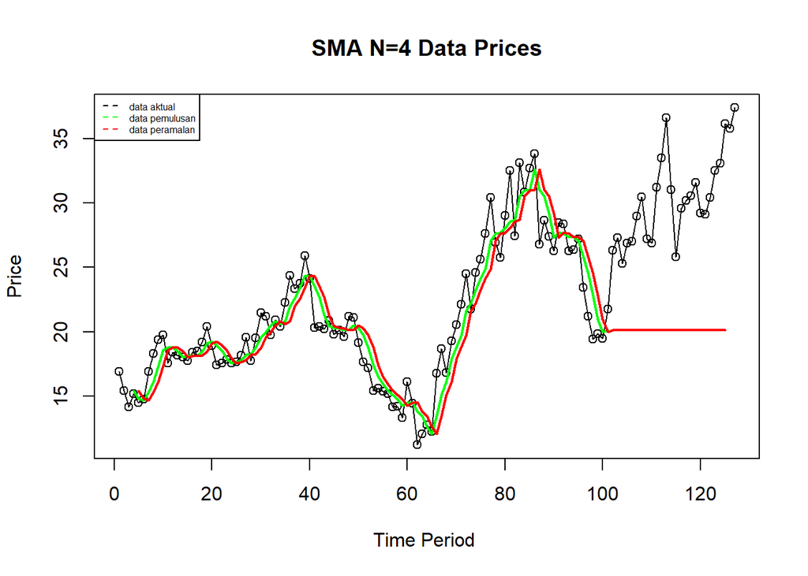

```r
ts.plot(dt.ts, xlab="Time Period ", ylab="Price", main= "SMA N=4 Data Prices")
points(dt.ts)
lines(data.gab[,2],col="green",lwd=2)
lines(data.gab[,3],col="red",lwd=2)
legend("topleft",c("data aktual","data pemulusan","data peramalan"), lty=8, col=c("black","green","red"), cex=0.5)
```

```r
#Menghitung nilai keakuratan data latih
error_train.sma = train_ma.ts-data.ramal[1:length(train_ma.ts)]

SSE_train.sma = sum(error_train.sma[5:length(train_ma.ts)]^2)
MSE_train.sma = mean(error_train.sma[5:length(train_ma.ts)]^2)
MAPE_train.sma = mean(abs((error_train.sma[5:length(train_ma.ts)]/train_ma.ts[5:length(train_ma.ts)])*100))

akurasi_train.sma <- matrix(c(SSE_train.sma, MSE_train.sma, MAPE_train.sma))
row.names(akurasi_train.sma)<- c("SSE", "MSE", "MAPE")
colnames(akurasi_train.sma) <- c("Akurasi m = 4")
akurasi_train.sma
```

```
##      Akurasi m = 4
## SSE     524.109731
## MSE       5.403193
## MAPE      8.792699
```

```r
#Menghitung nilai keakuratan data uji
error_test.sma = test_ma.ts-data.gab[97:120,3]
```

```r
SSE_test.sma = sum(error_test.sma^2)
MSE_test.sma = mean(error_test.sma^2)
MAPE_test.sma = mean(abs((error_test.sma/test_ma.ts*100)))

akurasi_test.sma <- matrix(c(SSE_test.sma, MSE_test.sma, MAPE_test.sma))
row.names(akurasi_test.sma)<- c("SSE", "MSE", "MAPE")
colnames(akurasi_test.sma) <- c("Akurasi m = 4")
akurasi_test.sma
```

```
##      Akurasi m = 4
## SSE     2644.29113
## MSE      101.70350
## MAPE      29.93222
```

Metode Simple Moving Average menghasilkan MAPE sebesar 29.93%, yang menunjukkan bahwa model memiliki tingkat kesalahan prediksi yang cukup tinggi dan kurang akurat dalam meramalkan data uji.

## DMA (Double Moving Average)

```r
dma <- SMA(data.sma, n = 4)
At <- 2*data.sma - dma
Bt <- 2/(4-1)*(data.sma - dma)
data.dma<- At+Bt
data.ramal2<- c(NA, data.dma)

t = 1:24
f = c()

for (i in t) {
  f[i] = At[length(At)] + Bt[length(Bt)]*(i)
}

data.gab2 <- cbind(aktual = c(dt.ts),
                   pemulusan1 = c(data.sma,rep(NA,24)),
                   pemulusan2 = c(dma, rep(NA,24)),
                   At = c(At, rep(NA,24)),
                   Bt = c(Bt,rep(NA,24)),
                   ramalan = c(data.ramal2, f[-1]))
data.gab2
```

```
##        aktual pemulusan1 pemulusan2       At           Bt   ramalan
##   [1,]  16.92         NA         NA       NA           NA        NA
##   [2,]  15.43         NA         NA       NA           NA        NA
##   [3,]  14.17         NA         NA       NA           NA        NA
##   [4,]  15.19    15.4275         NA       NA           NA        NA
##   [5,]  14.48    14.8175         NA       NA           NA        NA
##   [6,]  14.79    14.6575         NA       NA           NA        NA
##   [7,]  16.90    15.3400   15.06062 15.61938  0.186250000        NA
##   [8,]  18.31    16.1200   15.23375 17.00625  0.590833333 15.805625
##   [9,]  19.37    17.3425   15.86500 18.82000  0.985000000 17.597083
##  [10,]  19.77    18.5875   16.84750 20.32750  1.160000000 19.805000
##  [11,]  17.56    18.7525   17.70063 19.80437  0.701250000 21.487500
##  [12,]  18.39    18.7725   18.36375 19.18125  0.272500000 20.505625
##  [13,]  18.19    18.4775   18.64750 18.30750 -0.113333333 19.453750
##  [14,]  18.05    18.0475   18.51250 17.58250 -0.310000000 18.194167
```

[output cut: 113 more lines]

### Perbandingan

#### Plot

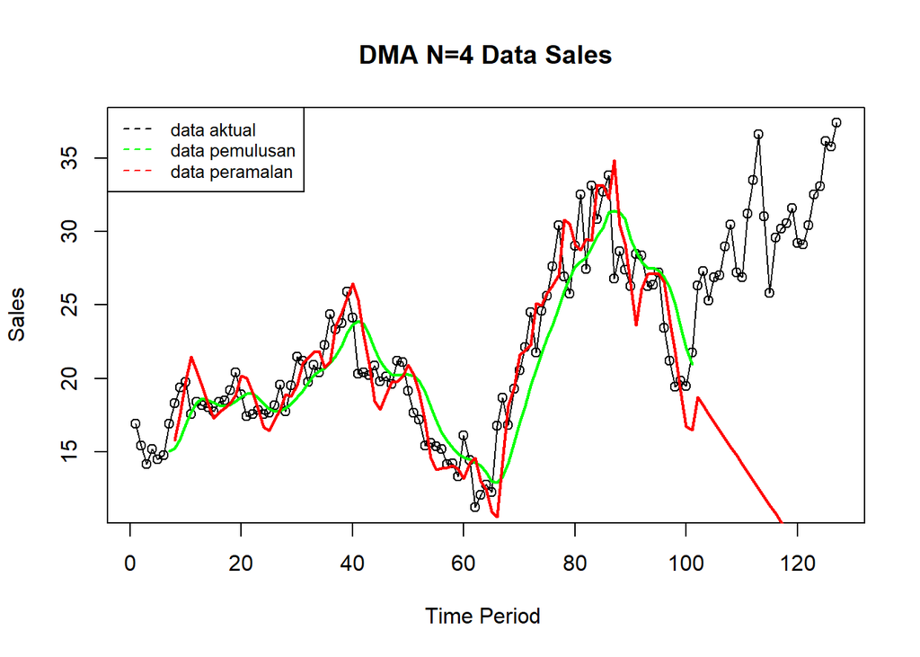

```r
ts.plot(dt.ts, xlab="Time Period ", ylab="Sales", main= "DMA N=4 Data Sales")
points(dt.ts)
lines(data.gab2[,3],col="green",lwd=2)
lines(data.gab2[,6],col="red",lwd=2)
legend("topleft",c("data aktual","data pemulusan","data peramalan"), lty=8, col=c("black","green","red"), cex=0.8)
```

#### Matriks akurasi

##### data latih

```r
#Menghitung nilai keakuratan data latih
error_train.dma = train_ma.ts-data.ramal2[1:length(train_ma.ts)]

SSE_train.dma = sum(error_train.dma[8:length(train_ma.ts)]^2)
MSE_train.dma = mean(error_train.dma[8:length(train_ma.ts)]^2)
MAPE_train.dma = mean(abs((error_train.dma[8:length(train_ma.ts)]/train_ma.ts[8:length(train_ma.ts)])*100))

akurasi_train.dma <- matrix(c(SSE_train.dma, MSE_train.dma, MAPE_train.dma))
row.names(akurasi_train.dma)<- c("SSE", "MSE", "MAPE")
colnames(akurasi_train.dma) <- c("Akurasi m = 4")
akurasi_train.dma
```

```
##      Akurasi m = 4
## SSE     499.935806
## MSE       5.318466
## MAPE      8.455068
```

Perhitungan akurasi pada data latih menggunakan nilai MAPE menghasilkan nilai MAPE yang kurang dari 10% sehingga dikategorikan sangat baik. Selanjutnya, perhitungan nilai akurasi dilakukan pada data uji.

##### data uji

```r
#Menghitung nilai keakuratan data uji
error_test.dma = test_ma.ts-data.gab2[97:120,6]
```

```r
SSE_test.dma = sum(error_test.dma^2)
MSE_test.dma = mean(error_test.dma^2)
MAPE_test.dma = mean(abs((error_test.dma/test_ma.ts*100)))

akurasi_test.dma <- matrix(c(SSE_test.dma, MSE_test.dma, MAPE_test.dma))
row.names(akurasi_test.dma)<- c("SSE", "MSE", "MAPE")
colnames(akurasi_test.dma) <- c("Akurasi m = 4")
akurasi_test.dma
```

```
##      Akurasi m = 4
## SSE     6680.25725
## MSE      256.93297
## MAPE      48.07938
```

Metode Double Moving Average menghasilkan MAPE sebesar 48.08%, yang menunjukkan bahwa model memiliki tingkat kesalahan prediksi yang tinggi dan kurang efektif dalam meramalkan data uji secara akurat.

# Kesimpulan

Pada data latih, metode DMA lebih baik dibandingkan dengan metode SMA, sedangkan pada data uji, metode SMA lebih baik dibandingkan DMA.

# SES & DES

```r
# jumlah baris data
n <- nrow(dt)

# hitung batas 80%
n_train <- floor(0.8 * n)

# bagi data
training <- dt[1:n_train, ]
testing  <- dt[(n_train+1):n, ]

# ubah ke time series
train.ts <- ts(training$price)
test.ts  <- ts(testing$price)
```

## Plot data

### semua data

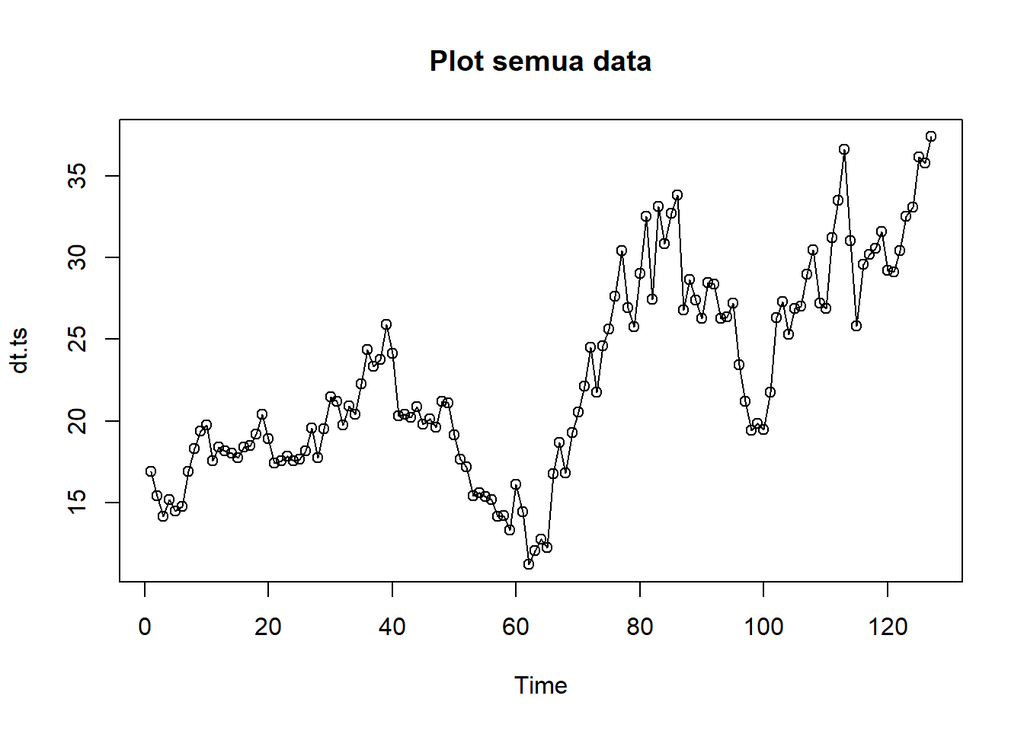

```r
#eksplorasi data
plot(dt.ts, col="black",main="Plot semua data")
points(dt.ts)
```

### data latih

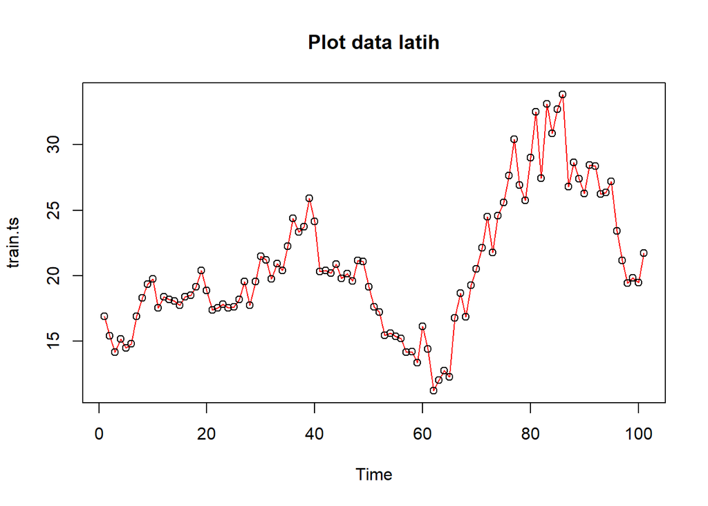

```r
plot(train.ts, col="red",main="Plot data latih")
points(train.ts)
```

### data uji

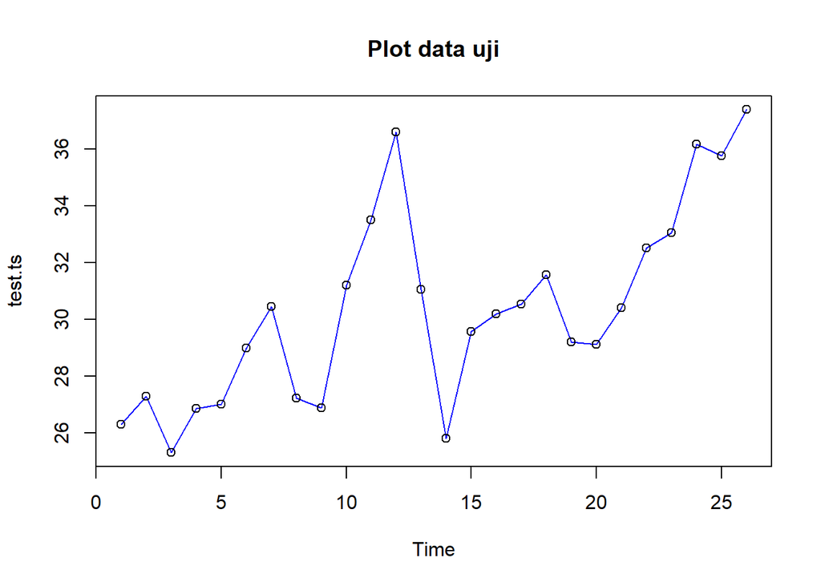

```r
plot(test.ts, col="blue",main="Plot data uji")
points(test.ts)
```

### ggplot

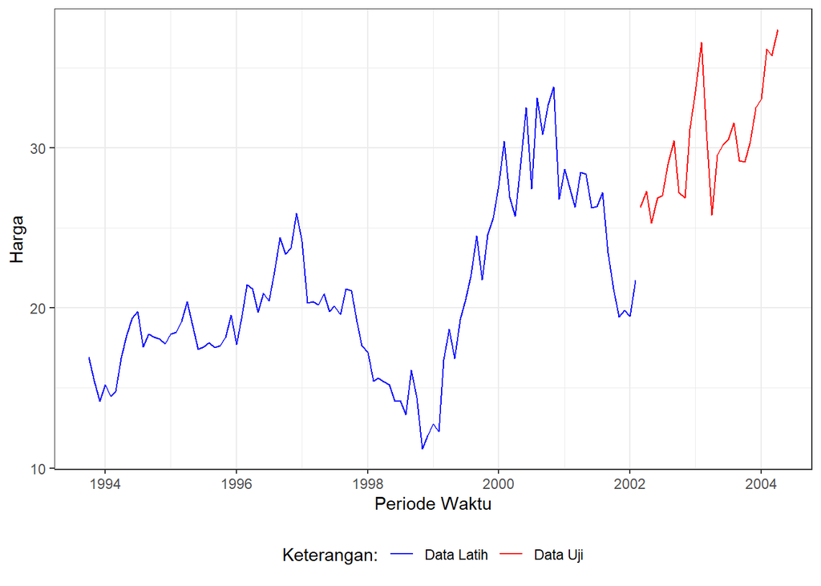

```r
#Eksplorasi dengan GGPLOT

ggplot() +
  geom_line(data = training, aes(x = date, y = price, col = "Data Latih")) +
  geom_line(data = testing, aes(x = date, y = price, col = "Data Uji")) +
  labs(x = "Periode Waktu", y = "Harga", color = "Legend") +
  scale_colour_manual(name="Keterangan:", breaks = c("Data Latih", "Data Uji"),
                      values = c("blue", "red")) +
  theme_bw() + theme(legend.position = "bottom",
                     plot.caption = element_text(hjust=0.5, size=12))
```

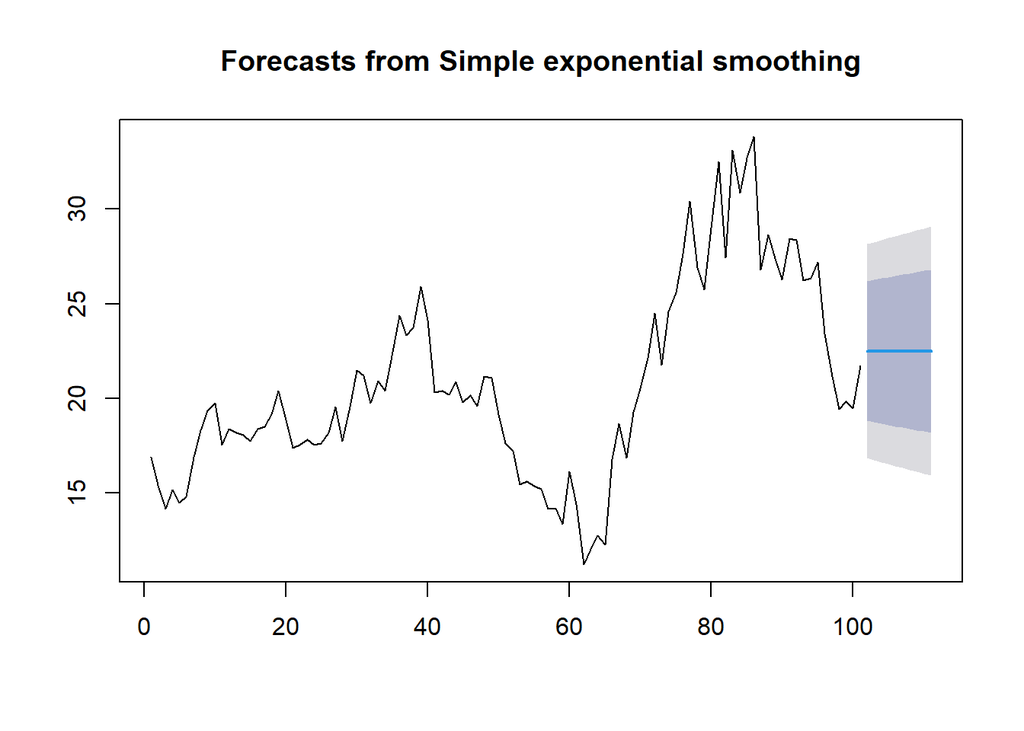

```r
ses.1 <- ses(train.ts, h = 10, alpha = 0.2)
plot(ses.1)
```

```r
ses.1
```

```
##     Point Forecast    Lo 80    Hi 80    Lo 95    Hi 95
## 102        22.5022 18.81268 26.19171 16.85957 28.14482
## 103        22.5022 18.73962 26.26478 16.74783 28.25657
## 104        22.5022 18.66794 26.33645 16.63821 28.36619
## 105        22.5022 18.59758 26.40681 16.53061 28.47379
## 106        22.5022 18.52847 26.47593 16.42491 28.57949
## 107        22.5022 18.46054 26.54386 16.32101 28.68338
## 108        22.5022 18.39373 26.61067 16.21884 28.78556
## 109        22.5022 18.32799 26.67641 16.11830 28.88610
## 110        22.5022 18.26327 26.74113 16.01932 28.98508
## 111        22.5022 18.19952 26.80487 15.92182 29.08257
```

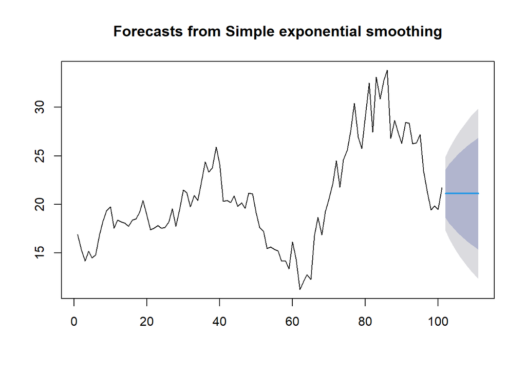

```r
ses.2<- ses(train.ts, h = 10, alpha = 0.7)
plot(ses.2)
```

```r
ses.2
```

```
##     Point Forecast    Lo 80    Hi 80    Lo 95    Hi 95
## 102       21.10576 18.63069 23.58083 17.32047 24.89105
## 103       21.10576 18.08455 24.12696 16.48522 25.72629
## 104       21.10576 17.62303 24.58849 15.77938 26.43213
## 105       21.10576 17.21588 24.99563 15.15671 27.05481
## 106       21.10576 16.84749 25.36403 14.59330 27.61822
## 107       21.10576 16.50852 25.70299 14.07489 28.13662
## 108       21.10576 16.19289 26.01863 13.59217 28.61934
## 109       21.10576 15.89634 26.31517 13.13864 29.07287
## 110       21.10576 15.61579 26.59572 12.70958 29.50194
## 111       21.10576 15.34889 26.86262 12.30140 29.91012
```

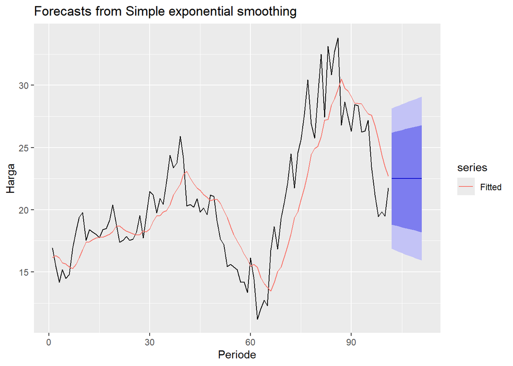

```r
autoplot(ses.1) +
  autolayer(fitted(ses.1), series="Fitted") +
  ylab("Harga") + xlab("Periode")
```

### Cara 2 (fungsi Holtwinter)

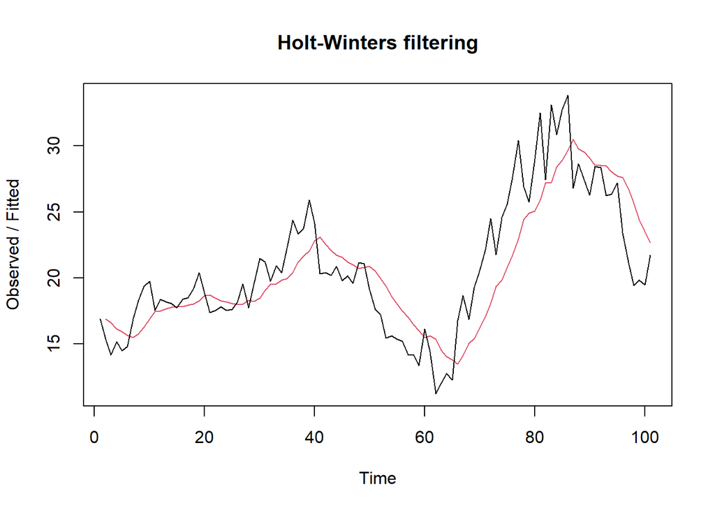

```r
ses1<- HoltWinters(train.ts, gamma = FALSE, beta = FALSE, alpha = 0.2)
plot(ses1)
```

```r
#ramalan
horizon <- length(testing$price)
ramalan1<- forecast(ses1, h=horizon)
ramalan1
```

```
##     Point Forecast    Lo 80    Hi 80    Lo 95    Hi 95
## 102        22.5022 18.82670 26.17770 16.88101 28.12339
## 103        22.5022 18.75391 26.25049 16.76969 28.23471
## 104        22.5022 18.68251 26.32189 16.66049 28.34391
## 105        22.5022 18.61242 26.39198 16.55329 28.45111
## 106        22.5022 18.54357 26.46083 16.44799 28.55640
## 107        22.5022 18.47589 26.52850 16.34449 28.65990
## 108        22.5022 18.40934 26.59506 16.24271 28.76169
## 109        22.5022 18.34385 26.66055 16.14255 28.86185
## 110        22.5022 18.27937 26.72502 16.04394 28.96045
## 111        22.5022 18.21587 26.78853 15.94682 29.05758
## 112        22.5022 18.15329 26.85111 15.85112 29.15328
## 113        22.5022 18.09160 26.91280 15.75677 29.24763
## 114        22.5022 18.03076 26.97363 15.66373 29.34067
## 115        22.5022 17.97074 27.03366 15.57193 29.43247
## 116        22.5022 17.91150 27.09289 15.48133 29.52306
## 117        22.5022 17.85302 27.15138 15.39189 29.61250
## 118        22.5022 17.79526 27.20913 15.30356 29.70083
## 119        22.5022 17.73821 27.26619 15.21630 29.78809
## 120        22.5022 17.68183 27.32257 15.13008 29.87432
## 121        22.5022 17.62610 27.37830 15.04485 29.95955
## 122        22.5022 17.57100 27.43340 14.96058 30.04382
## 123        22.5022 17.51651 27.48789 14.87725 30.12715
## 124        22.5022 17.46261 27.54179 14.79481 30.20959
## 125        22.5022 17.40928 27.59512 14.71325 30.29115
## 126        22.5022 17.35650 27.64790 14.63253 30.37186
## 127        22.5022 17.30426 27.70014 14.55264 30.45176
```

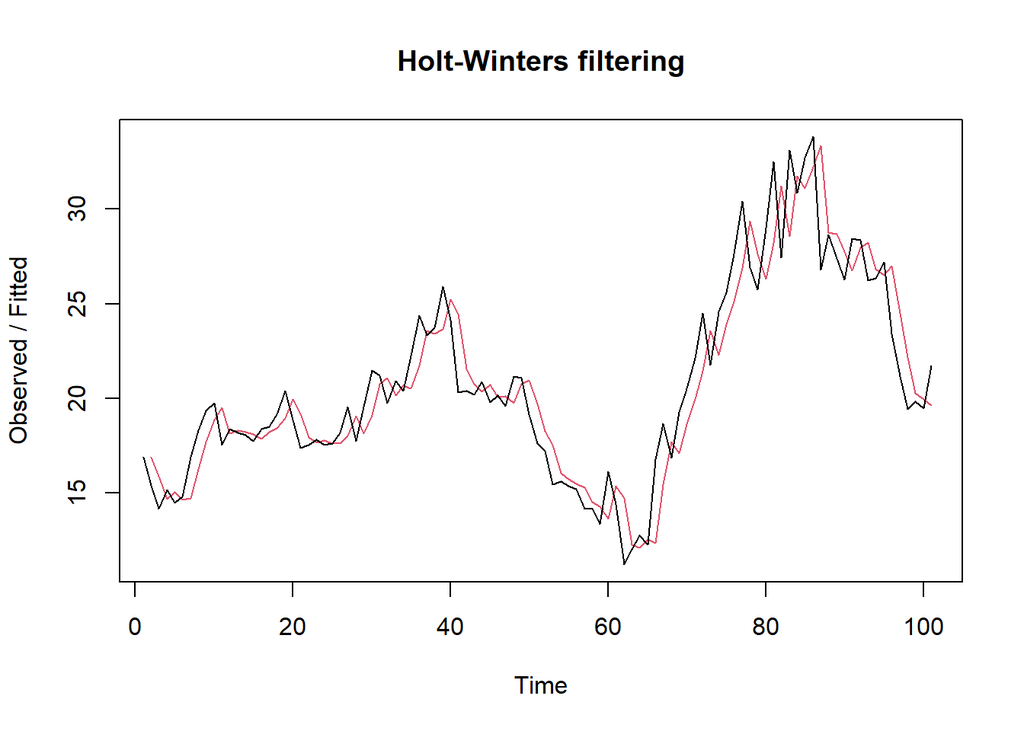

```r
ses2<- HoltWinters(train.ts, gamma = FALSE, beta = FALSE, alpha = 0.7)
plot(ses2)
```

```r
#ramalan
ramalan2<- forecast(ses2, h=horizon)
ramalan2
```

```
##     Point Forecast    Lo 80    Hi 80     Lo 95    Hi 95
## 102       21.10576 18.63083 23.58068 17.320681 24.89083
## 103       21.10576 18.08472 24.12679 16.485483 25.72603
## 104       21.10576 17.62322 24.58829 15.779683 26.43183
## 105       21.10576 17.21610 24.99541 15.157043 27.05447
## 106       21.10576 16.84773 25.36378 14.593666 27.61785
## 107       21.10576 16.50878 25.70273 14.075290 28.13622
## 108       21.10576 16.19316 26.01835 13.592596 28.61892
## 109       21.10576 15.89664 26.31488 13.139094 29.07242
## 110       21.10576 15.61610 26.59541 12.710053 29.50146
## 111       21.10576 15.34922 26.86229 12.301895 29.90962
## 112       21.10576 15.09418 27.11734 11.911840 30.29967
## 113       21.10576 14.84952 27.36199 11.537672 30.67384
## 114       21.10576 14.61408 27.59743 11.177596 31.03392
## 115       21.10576 14.38689 27.82463 10.830130 31.38138
## 116       21.10576 14.16712 28.04439 10.494035 31.71748
## 117       21.10576 13.95411 28.25740 10.168263 32.04325
## 118       21.10576 13.74727 28.46425  9.851917 32.35960
## 119       21.10576 13.54608 28.66544  9.544224 32.66729
## 120       21.10576 13.35010 28.86141  9.244511 32.96700
## 121       21.10576 13.15896 29.05255  8.952186 33.25933
## 122       21.10576 12.97231 29.23920  8.666728 33.54478
## 123       21.10576 12.78985 29.42166  8.387677 33.82384
## 124       21.10576 12.61131 29.60021  8.114618 34.09690
## 125       21.10576 12.43644 29.77507  7.847181 34.36433
## 126       21.10576 12.26503 29.94648  7.585034 34.62648
## 127       21.10576 12.09688 30.11463  7.327873 34.88364
```

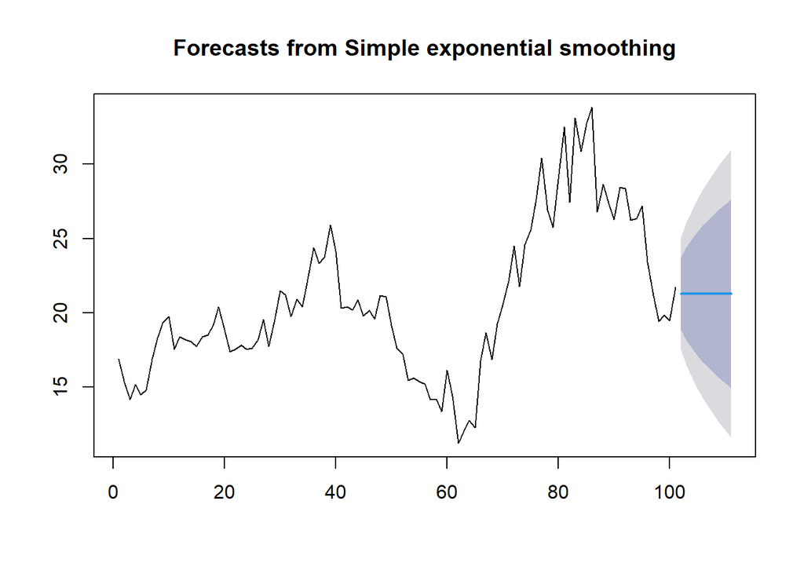

```r
#SES
ses.opt <- ses(train.ts, h = 10, alpha = NULL)
plot(ses.opt)
```

```r
ses.opt
```

```
##     Point Forecast    Lo 80    Hi 80    Lo 95    Hi 95
## 102       21.28346 18.82018 23.74674 17.51621 25.05071
## 103       21.28346 18.14331 24.42361 16.48102 26.08590
## 104       21.28346 17.58842 24.97850 15.63239 26.93453
## 105       21.28346 17.10661 25.46031 14.89552 27.67140
## 106       21.28346 16.67489 25.89203 14.23527 28.33165
## 107       21.28346 16.28029 26.28663 13.63178 28.93514
## 108       21.28346 15.91462 26.65230 13.07253 29.49439
## 109       21.28346 15.57231 26.99461 12.54901 30.01791
## 110       21.28346 15.24939 27.31753 12.05514 30.51178
## 111       21.28346 14.94289 27.62403 11.58640 30.98052
```

```r
#Lamda Optimum Holt Winter
HWopt<- HoltWinters(train.ts, gamma = FALSE, beta = FALSE,alpha = NULL)
HWopt
```

```
## Holt-Winters exponential smoothing without trend and without seasonal component.
##
## Call:
## HoltWinters(x = train.ts, alpha = NULL, beta = FALSE, gamma = FALSE)
##
## Smoothing parameters:
##  alpha: 0.7925175
##  beta : FALSE
##  gamma: FALSE
##
## Coefficients:
##       [,1]
## a 21.28739
```

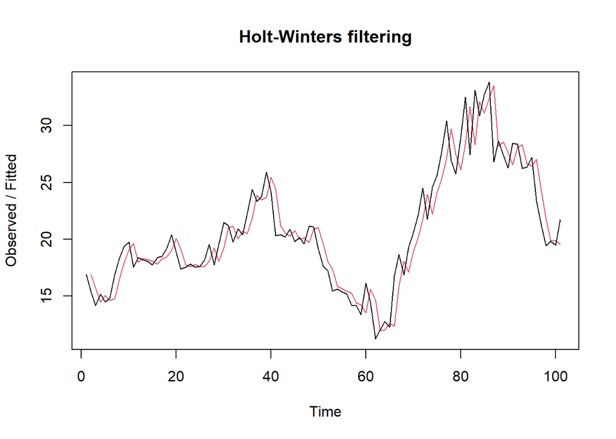

```r
plot(HWopt)
```

```r
#ramalan
ramalanopt<- forecast(HWopt, h=horizon)
ramalanopt
```

```
##     Point Forecast    Lo 80    Hi 80     Lo 95    Hi 95
## 102       21.28739 18.82469 23.75009 17.521015 25.05377
## 103       21.28739 18.14507 24.42971 16.481631 26.09315
## 104       21.28739 17.58828 24.98650 15.630088 26.94470
## 105       21.28739 17.10497 25.46982 14.890922 27.68386
## 106       21.28739 16.67199 25.90280 14.228740 28.34604
## 107       21.28739 16.27628 26.29850 13.623560 28.95122
## 108       21.28739 15.90961 26.66517 13.062791 29.51199
## 109       21.28739 15.56640 27.00838 12.537889 30.03690
## 110       21.28739 15.24264 27.33214 12.042742 30.53204
## 111       21.28739 14.93536 27.63942 11.572800 31.00198
## 112       21.28739 14.64228 27.93251 11.124565 31.45022
## 113       21.28739 14.36158 28.21320 10.695282 31.87950
## 114       21.28739 14.09183 28.48295 10.282732 32.29205
## 115       21.28739 13.83183 28.74295  9.885099 32.68968
## 116       21.28739 13.58060 28.99418  9.500873 33.07391
## 117       21.28739 13.33731 29.23748  9.128783 33.44600
## 118       21.28739 13.10124 29.47355  8.767747 33.80704
## 119       21.28739 12.87179 29.70300  8.416834 34.15795
## 120       21.28739 12.64843 29.92635  8.075238 34.49955
## 121       21.28739 12.43070 30.14408  7.742255 34.83253
## 122       21.28739 12.21820 30.35658  7.417263 35.15752
## 123       21.28739 12.01057 30.56422  7.099713 35.47507
## 124       21.28739 11.80748 30.76730  6.789117 35.78567
## 125       21.28739 11.60865 30.96613  6.485037 36.08975
## 126       21.28739 11.41383 31.16096  6.187078 36.38771
## 127       21.28739 11.22277 31.35201  5.894887 36.67990
```

### Akurasi

#### data latih

```r
#Keakuratan Metode
#Pada data training

# SES dengan alpha = 0.2
SSE1<-ses1$SSE
MSE1<-ses1$SSE/length(train.ts)
RMSE1<-sqrt(MSE1)

akurasi1 <- matrix(c(SSE1,MSE1,RMSE1))
row.names(akurasi1)<- c("SSE", "MSE", "RMSE")
colnames(akurasi1) <- c("Akurasi lamda=0.2")
akurasi1
```

```
##      Akurasi lamda=0.2
## SSE         822.110978
## MSE           8.139713
## RMSE          2.853018
```

```r
# SES dengan alpha = 0.7
SSE2<-ses2$SSE
MSE2<-ses2$SSE/length(train.ts)
RMSE2<-sqrt(MSE2)

akurasi2 <- matrix(c(SSE2,MSE2,RMSE2))
row.names(akurasi2)<- c("SSE", "MSE", "RMSE")
colnames(akurasi2) <- c("Akurasi lamda=0.7")
akurasi2
```

```
##      Akurasi lamda=0.7
## SSE         369.580060
## MSE           3.659209
## RMSE          1.912906
```

```r
#Cara Manual
# Alpha = 0.2
fitted1<-ramalan1$fitted
sisaan1<-ramalan1$residuals
head(sisaan1)
```

```
## Time Series:
## Start = 1
## End = 6
## Frequency = 1
## [1]        NA -1.490000 -2.452000 -0.941600 -1.463280 -0.860624
```

```r
resid1<-training$price-ramalan1$fitted
head(resid1)
```

```
## Time Series:
## Start = 1
## End = 6
## Frequency = 1
## [1]        NA -1.490000 -2.452000 -0.941600 -1.463280 -0.860624
```

```r
SSE.1=sum(sisaan1[2:length(train.ts)]^2)
SSE.1
```

```
## [1] 822.111
```

```r
MSE.1 = SSE.1/length(train.ts)
MSE.1
```

```
## [1] 8.139713
```

```r
MAPE.1 = sum(abs(sisaan1[2:length(train.ts)]/train.ts[2:length(train.ts)])*
               100)/length(train.ts)
MAPE.1
```

```
## [1] 11.08697
```

```r
akurasi.1 <- matrix(c(SSE.1,MSE.1,MAPE.1))
row.names(akurasi.1)<- c("SSE", "MSE", "MAPE")
colnames(akurasi.1) <- c("Akurasi lamda=0.2")
akurasi.1
```

```
##      Akurasi lamda=0.2
## SSE         822.110978
## MSE           8.139713
## MAPE         11.086968
```

```r
# Alpha = 0.7
fitted2<-ramalan2$fitted
sisaan2<-ramalan2$residuals
head(sisaan2)
```

```
## Time Series:
## Start = 1
## End = 6
## Frequency = 1
## [1]        NA -1.490000 -1.707000  0.507900 -0.557630  0.142711
```

```r
resid2<-training$price-ramalan2$fitted
head(resid2)
```

```
## Time Series:
## Start = 1
## End = 6
## Frequency = 1
## [1]        NA -1.490000 -1.707000  0.507900 -0.557630  0.142711
```

```r
SSE.2=sum(sisaan2[2:length(train.ts)]^2)
SSE.2
```

```
## [1] 369.5801
```

```r
MSE.2 = SSE.2/length(train.ts)
MSE.2
```

```
## [1] 3.659209
```

```r
MAPE.2 = sum(abs(sisaan2[2:length(train.ts)]/train.ts[2:length(train.ts)])*
               100)/length(train.ts)
MAPE.2
```

```
## [1] 7.012792
```

```r
akurasi.2 <- matrix(c(SSE.2,MSE.2,MAPE.2))
row.names(akurasi.2)<- c("SSE", "MSE", "MAPE")
colnames(akurasi.2) <- c("Akurasi lamda=0.7")
akurasi.2
```

```
##      Akurasi lamda=0.7
## SSE         369.580060
## MSE           3.659209
## MAPE          7.012792
```

#### data uji

```r
# jumlah observasi uji
n_test <- nrow(testing)

# error (ramalan - aktual), samakan panjang dan tipe numeric
e1   <- as.numeric(ramalan1$mean)[1:n_test] - as.numeric(testing$price)
e2   <- as.numeric(ramalan2$mean)[1:n_test] - as.numeric(testing$price)
eopt <- as.numeric(ramalanopt$mean)[1:n_test] - as.numeric(testing$price)

# SSE / MSE / RMSE untuk masing-masing model (abaikan NA)
SSEtesting1  <- sum(e1^2,  na.rm = TRUE)
MSEtesting1  <- mean(e1^2, na.rm = TRUE)
RMSEtesting1 <- sqrt(MSEtesting1)

SSEtesting2  <- sum(e2^2,  na.rm = TRUE)
MSEtesting2  <- mean(e2^2, na.rm = TRUE)
RMSEtesting2 <- sqrt(MSEtesting2)

SSEtestingopt  <- sum(eopt^2,  na.rm = TRUE)
MSEtestingopt  <- mean(eopt^2, na.rm = TRUE)
RMSEtestingopt <- sqrt(MSEtestingopt)

# Tabel ringkas
akurasitesting_SSE <- matrix(c(SSEtesting1, SSEtesting2, SSEtestingopt),
                             nrow = 3,
                             dimnames = list(c("SSE1","SSE2","SSEopt"), "Nilai"))
akurasitesting_MSE <- matrix(c(MSEtesting1, MSEtesting2, MSEtestingopt),
                             nrow = 3,
                             dimnames = list(c("MSE1","MSE2","MSEopt"), "Nilai"))
akurasitesting_RMSE <- matrix(c(RMSEtesting1, RMSEtesting2, RMSEtestingopt),
                              nrow = 3,
                              dimnames = list(c("RMSE1","RMSE2","RMSEopt"), "Nilai"))

akurasitesting_SSE
```

```
##           Nilai
## SSE1   1912.757
## SSE2   2535.645
## SSEopt 2448.889
```

```r
akurasitesting_MSE
```

```
##           Nilai
## MSE1   73.56759
## MSE2   97.52480
## MSEopt 94.18803
```

```r
akurasitesting_RMSE
```

```
##            Nilai
## RMSE1   8.577155
## RMSE2   9.875464
## RMSEopt 9.705052
```

```r
# pakai packages forecast
accuracy(ramalan1, testing$price)
```

```
##                     ME     RMSE      MAE        MPE     MAPE     MASE      ACF1
## Training set 0.2791099 2.867248 2.299596 -0.2693295 11.19784 1.548549 0.7311181
## Test set     7.8797249 8.577155 7.879725 25.0416074 25.04161 5.306212        NA
```

```r
accuracy(ramalan2, testing$price)
```

```
##                      ME     RMSE      MAE        MPE     MAPE      MASE
## Training set 0.05979652 1.922447 1.481051 -0.2213554  7.08292 0.9973409
## Test set     9.27616650 9.875464 9.276166 29.6933760 29.69338 6.2465768
##                    ACF1
## Training set 0.09401698
## Test set             NA
```

```r
accuracy(ramalanopt, testing$price)
```

```
##                      ME     RMSE      MAE        MPE      MAPE      MASE
## Training set 0.05510783 1.912818 1.463402 -0.1969874  6.975593 0.9854558
## Test set     9.09453111 9.705052 9.094531 29.0883197 29.088320 6.1242634
##                       ACF1
## Training set -0.0006320494
## Test set                NA
```

## DSE (Double Exponential Smoothing)

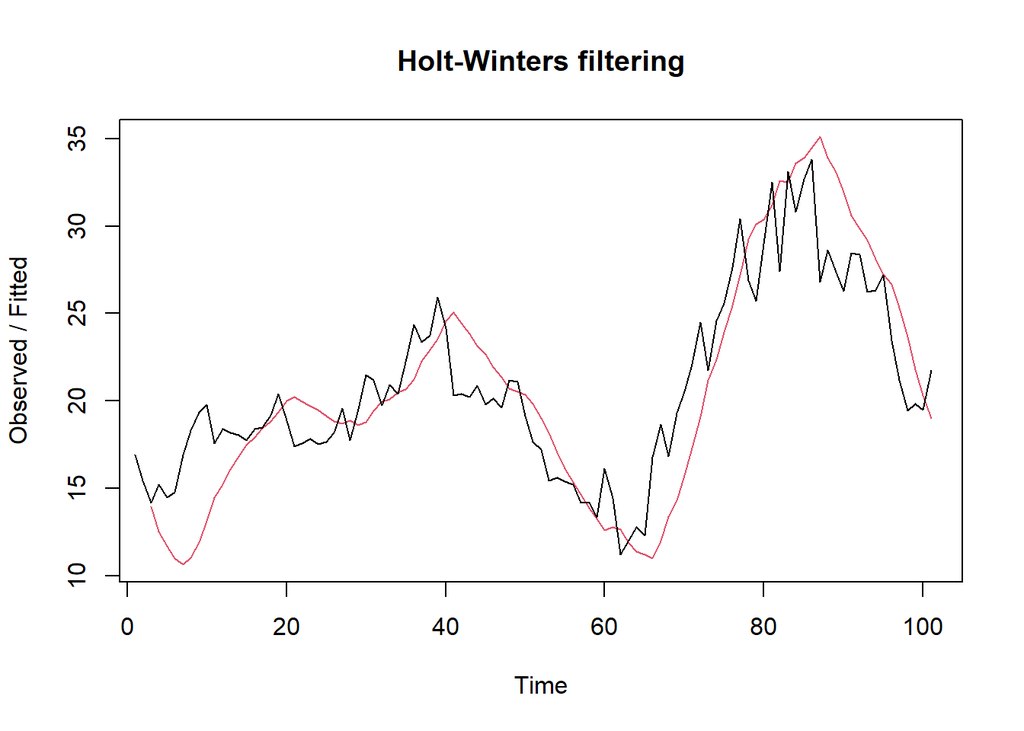

```r
#Lamda=0.2 dan gamma=0.2
des.1<- HoltWinters(train.ts, gamma = FALSE, beta = 0.2, alpha = 0.2)
plot(des.1)
```

```r
#ramalan
ramalandes1<- forecast(des.1, h=horizon)
ramalandes1
```

```
##     Point Forecast       Lo 80     Hi 80      Lo 95    Hi 95
## 102     18.5354807  14.5776431 22.493318  12.482490 24.58847
## 103     17.5149298  13.4447022 21.585157  11.290054 23.73981
## 104     16.4943788  12.2759848 20.712773  10.042902 22.94586
## 105     15.4738279  11.0694107 19.878245   8.737853 22.20980
## 106     14.4532770   9.8241294 19.082425   7.373607 21.53295
## 107     13.4327260   8.5403520 18.325100   5.950486 20.91497
## 108     12.4121751   7.2191060 17.605244   4.470061 20.35429
## 109     11.3916241   5.8619711 16.921277   2.934750 19.84850
## 110     10.3710732   4.4708412 16.271305   1.347447 19.39470
## 111      9.3505223   3.0477357 15.653309  -0.288758 18.98980
## 112      8.3299713   1.5946665 15.065276  -1.970788 18.63073
## 113      7.3094204   0.1135534 14.505287  -3.695708 18.31455
## 114      6.2888694  -1.3938226 13.971561  -5.460794 18.03853
## 115      5.2683185  -2.9258393 13.462476  -7.263564 17.80020
## 116      4.2477676  -4.4810368 12.976572  -9.101787 17.59732
## 117      3.2272166  -6.0581101 12.512543 -10.973465 17.42790
## 118      2.2066657  -7.6558973 12.069229 -12.876823 17.29015
## 119      1.1861147  -9.2733652 11.645595 -14.810279 17.18251
## 120      0.1655638 -10.9095947 11.240722 -16.772429 17.10356
## 121     -0.8549871 -12.5637667 10.853792 -18.762020 17.05205
## 122     -1.8755381 -14.2351496 10.484073 -20.777933 17.02686
## 123     -2.8960890 -15.9230879 10.130910 -22.819164 17.02699
## 124     -3.9166400 -17.6269918  9.793712 -24.884814 17.05153
## 125     -4.9371909 -19.3463293  9.471947 -26.974066 17.09968
## 126     -5.9577418 -21.0806183  9.165135 -29.086185 17.17070
## 127     -6.9782928 -22.8294202  8.872835 -31.220500 17.26391
```

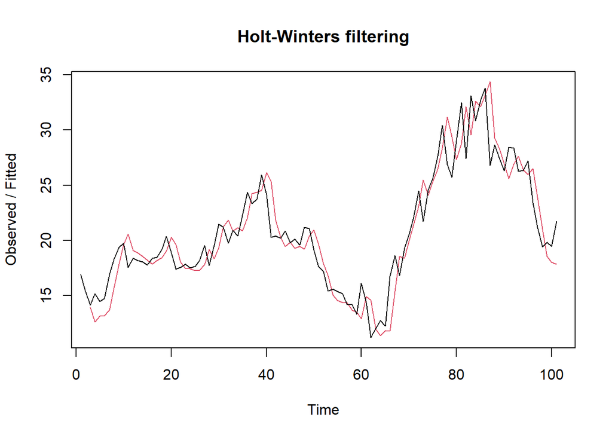

```r
#Lamda=0.6 dan gamma=0.3
des.2<- HoltWinters(train.ts, gamma = FALSE, beta = 0.3, alpha = 0.6)
plot(des.2)
```

```r
#ramalan
ramalandes2<- forecast(des.2, h=horizon)
ramalandes2
```

```
##     Point Forecast       Lo 80    Hi 80        Lo 95    Hi 95
## 102       19.85544  17.2309676 22.47992  15.84165404 23.86923
## 103       19.51952  16.1910897 22.84795  14.42912460 24.60992
## 104       19.18360  15.0091145 23.35808  12.79927595 25.56792
## 105       18.84768  13.7117443 23.98361  10.99294601 26.70241
## 106       18.51175  12.3166569 24.70685   9.03717053 27.98634
## 107       18.17583  10.8357402 25.51592   6.95013046 29.40153
## 108       17.83991   9.2773586 26.40246   4.74461795 30.93520
## 109       17.50399   7.6476915 27.36028   2.43008377 32.57789
## 110       17.16806   5.9515084 28.38462   0.01382217 34.32231
## 111       16.83214   4.1926278 29.47166  -2.49832707 36.16261
## 112       16.49622   2.3741990 30.61824  -5.10154737 38.09399
## 113       16.16030   0.4988828 31.82171  -7.79176946 40.11237
## 114       15.82438  -1.4310289 33.07978 -10.56548828 42.21424
## 115       15.48845  -3.4135309 34.39044 -13.41963689 44.39654
## 116       15.15253  -5.4468457 35.75191 -16.35149701 46.65656
## 117       14.81661  -7.5293811 37.16260 -19.35863355 48.99185
## 118       14.48069  -9.6596981 38.62107 -22.43884563 51.40022
## 119       14.14476 -11.8364861 40.12601 -25.59012900 53.87966
## 120       13.80884 -14.0585439 41.67623 -28.81064665 56.42833
## 121       13.47292 -16.3247645 43.27060 -32.09870549 59.04454
## 122       13.13700 -18.6341227 44.90812 -35.45273749 61.72673
## 123       12.80107 -20.9856648 46.58781 -38.87128419 64.47343
## 124       12.46515 -23.3785004 48.30880 -42.35298396 67.28329
## 125       12.12923 -25.8117955 50.07026 -45.89656123 70.15502
## 126       11.79331 -28.2847666 51.87138 -49.50081747 73.08743
## 127       11.45739 -30.7966750 53.71145 -53.16462339 76.07939
```

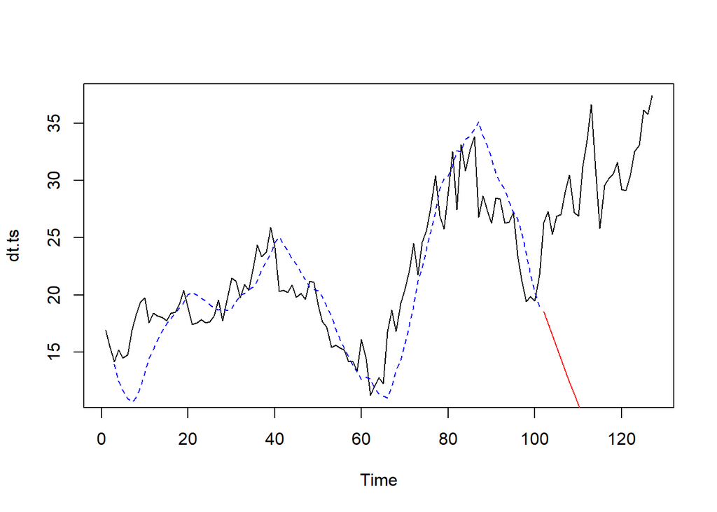

```r
plot(dt.ts)
lines(des.1$fitted[,1], lty=2, col="blue")
lines(ramalandes1$mean, col="red")
```

```r
#Lamda dan gamma optimum
des.opt<- HoltWinters(train.ts, gamma = FALSE)
des.opt
```

```
## Holt-Winters exponential smoothing with trend and without seasonal component.
##
## Call:
## HoltWinters(x = train.ts, gamma = FALSE)
##
## Smoothing parameters:
##  alpha: 0.743734
##  beta : 0.1558947
##  gamma: FALSE
##
## Coefficients:
##         [,1]
## a 20.9013367
## b -0.4278584
```

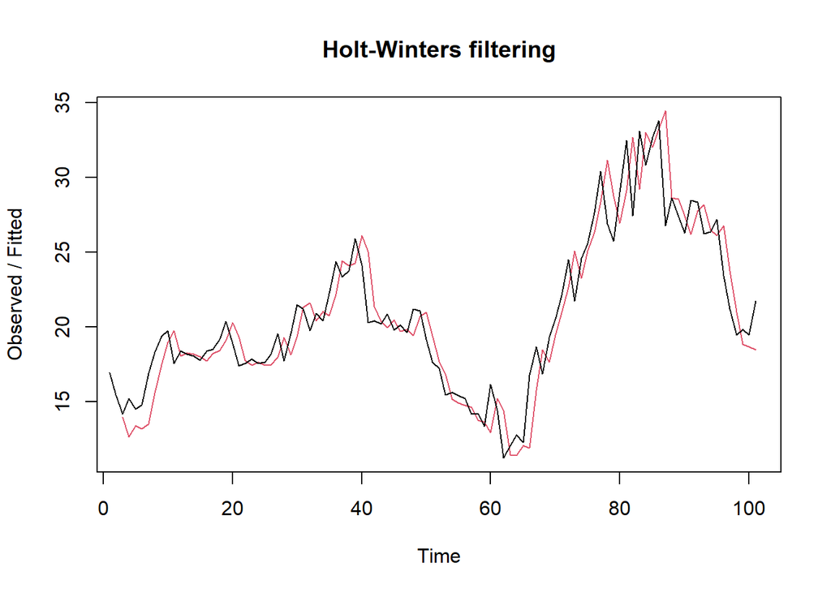

```r
plot(des.opt)
```

```r
#ramalan
ramalandesopt<- forecast(des.opt, h=horizon)
ramalandesopt
```

```
##     Point Forecast       Lo 80    Hi 80        Lo 95    Hi 95
## 102      20.473478  17.8929051 23.05405  16.52683225 24.42012
## 103      20.045620  16.6425428 23.44870  14.84106271 25.25018
## 104      19.617761  15.3846101 23.85091  13.14371524 26.09181
## 105      19.189903  14.1051895 24.27462  11.41350471 26.96630
## 106      18.762045  12.7984715 24.72562   9.64154664 27.88254
## 107      18.334186  11.4619020 25.20647   7.82393451 28.84444
## 108      17.906328  10.0944385 25.71822   5.95907408 29.85358
## 109      17.478469   8.6958034 26.26114   4.04654086 30.91040
## 110      17.050611   7.2661255 26.83510   2.08653176 32.01469
## 111      16.622752   5.8057538 27.43975   0.07958059 33.16592
## 112      16.194894   4.3151558 28.07463  -1.97359778 34.36339
## 113      15.767036   2.7948592 28.73921  -4.07219623 35.60627
## 114      15.339177   1.2454181 29.43294  -6.21536735 36.89372
## 115      14.911319  -0.3326072 30.15524  -8.40225420 38.22489
## 116      14.483460  -1.9386621 30.90558 -10.63200860 39.59893
## 117      14.055602  -3.5722048 31.68341 -12.90380195 41.01501
## 118      13.627743  -5.2327102 32.48820 -15.21683126 42.47232
## 119      13.199885  -6.9196722 33.31944 -17.57032238 43.97009
## 120      12.772027  -8.6326042 34.17666 -19.96353135 45.50758
## 121      12.344168 -10.3710398 35.05938 -22.39574460 47.08408
## 122      11.916310 -12.1345320 35.96715 -24.86627850 48.69890
## 123      11.488451 -13.9226526 36.89956 -27.37447844 50.35138
## 124      11.060593 -15.7349919 37.85618 -29.91971765 52.04090
## 125      10.632735 -17.5711574 38.83663 -32.50139592 53.76686
## 126      10.204876 -19.4307732 39.84053 -35.11893827 55.52869
## 127       9.777018 -21.3134789 40.86751 -37.77179363 57.32583
```

### Akurasi

#### data latih

```r
#Akurasi Data Training
ssedes.train1<-des.1$SSE
msedes.train1<-ssedes.train1/length(train.ts)
sisaandes1<-ramalandes1$residuals
head(sisaandes1)
```

```
## Time Series:
## Start = 1
## End = 6
## Frequency = 1
## [1]       NA       NA 0.230000 2.684800 2.811248 3.819956
```

```r
mapedes.train1 <- sum(abs(sisaandes1[3:length(train.ts)]/train.ts[3:length(train.ts)])
                      *100)/length(train.ts)

akurasides.1 <- matrix(c(ssedes.train1,msedes.train1,mapedes.train1))
row.names(akurasides.1)<- c("SSE", "MSE", "MAPE")
colnames(akurasides.1) <- c("Akurasi lamda=0.2 dan gamma=0.2")
akurasides.1
```

```
##      Akurasi lamda=0.2 dan gamma=0.2
## SSE                        936.08617
## MSE                          9.26818
## MAPE                        11.55529
```

```r
ssedes.train2<-des.2$SSE
msedes.train2<-ssedes.train2/length(train.ts)
sisaandes2<-ramalandes2$residuals
head(sisaandes2)
```

```
## Time Series:
## Start = 1
## End = 6
## Frequency = 1
## [1]       NA       NA 0.230000 2.560600 1.301932 1.584117
```

```r
mapedes.train2 <- sum(abs(sisaandes2[3:length(train.ts)]/train.ts[3:length(train.ts)])
                      *100)/length(train.ts)

akurasides.2 <- matrix(c(ssedes.train2,msedes.train2,mapedes.train2))
row.names(akurasides.2)<- c("SSE", "MSE", "MAPE")
colnames(akurasides.2) <- c("Akurasi lamda=0.6 dan gamma=0.3")
akurasides.2
```

```
##      Akurasi lamda=0.6 dan gamma=0.3
## SSE                       411.412607
## MSE                         4.073392
## MAPE                        7.292216
```

## data uji

```r
#Akurasi Data Testing
selisihdes1<-ramalandes1$mean-testing$price
selisihdes1
```

```
## Time Series:
## Start = 102
## End = 127
## Frequency = 1
##  [1]  -7.774519  -9.775070  -8.815621 -11.386172 -12.566723 -15.547274
##  [7] -18.037825 -15.828376 -16.518927 -21.849478 -25.180029 -29.290580
## [13] -24.751131 -20.531682 -25.312232 -26.962783 -28.333334 -30.383885
## [19] -29.034436 -29.964987 -32.285538 -35.416089 -36.966640 -41.097191
## [25] -41.717742 -44.358293
```

```r
SSEtestingdes1<-sum(selisihdes1^2)
MSEtestingdes1<-SSEtestingdes1/length(testing$price)
MAPEtestingdes1<-sum(abs(selisihdes1/testing$price)*100)/length(testing$price)

selisihdes2<-ramalandes2$mean-testing$price
selisihdes2
```

```
## Time Series:
## Start = 102
## End = 127
## Frequency = 1
##  [1]  -6.454557  -7.770479  -6.126401  -8.012324  -8.508246 -10.804168
##  [7] -12.610091  -9.716013  -9.721935 -14.367858 -17.013780 -20.439702
## [13] -15.215624 -10.311547 -14.407469 -15.373391 -16.059314 -17.425236
## [19] -15.391158 -15.637081 -17.273003 -19.718925 -20.584848 -24.030770
## [25] -23.966692 -25.922615
```

```r
SSEtestingdes2<-sum(selisihdes2^2)
MSEtestingdes2<-SSEtestingdes2/length(testing$price)
MAPEtestingdes2<-sum(abs(selisihdes2/testing$price)*100)/length(testing$price)

selisihdesopt<-ramalandesopt$mean-testing$price
selisihdesopt
```

```
## Time Series:
## Start = 102
## End = 127
## Frequency = 1
##  [1]  -5.836522  -7.244380  -5.692239  -7.670097  -8.257955 -10.645814
##  [7] -12.543672  -9.741531  -9.839389 -14.577248 -17.315106 -20.832964
## [13] -15.700823 -10.888681 -15.076540 -16.134398 -16.912257 -18.370115
## [19] -16.427973 -16.765832 -18.493690 -21.031549 -21.989407 -25.527265
## [25] -25.555124 -27.602982
```

```r
SSEtestingdesopt<-sum(selisihdesopt^2)
MSEtestingdesopt<-SSEtestingdesopt/length(testing$price)
MAPEtestingdesopt<-sum(abs(selisihdesopt/testing$price)*100)/length(testing$price)

akurasitestingdes <-
  matrix(c(SSEtestingdes1,MSEtestingdes1,MAPEtestingdes1,SSEtestingdes2,MSEtestingdes2,
           MAPEtestingdes2,SSEtestingdesopt,MSEtestingdesopt,MAPEtestingdesopt),
         nrow=3,ncol=3)
row.names(akurasitestingdes)<- c("SSE", "MSE", "MAPE")
colnames(akurasitestingdes) <- c("des ske1","des ske2","des opt")
akurasitestingdes
```

```
##         des ske1   des ske2    des opt
## SSE  18510.06412 6414.00566 7016.34530
## MSE    711.92554  246.69253  269.85943
## MAPE    78.78159   47.19789   48.78991
```

### Perbandingan SES & DES

```r
MSEfull <-
  matrix(c(MSEtesting1,MSEtesting2,MSEtestingopt,MSEtestingdes1,MSEtestingdes2,
           MSEtestingdesopt),nrow=3,ncol=2)
row.names(MSEfull)<- c("ske 1", "ske 2", "ske opt")
colnames(MSEfull) <- c("ses","des")
MSEfull
```

```
##              ses      des
## ske 1   73.56759 711.9255
## ske 2   97.52480 246.6925
## ske opt 94.18803 269.8594
```

1 -> alpha = 0.2 2 -> alpha = 0.7 opt -> alpha = null

# Kesimpulan

Jika dilihat dari MAPE, nilai terendah didapat pada metode SES.